# Unsupervised Modeling: Clustering

## 3.1 Exploring OPTICS (MinPts search)

To avoid optimizing density blindly, we use OPTICS as a visual topographic tool. Although this algorithm does not require a fixed Epsilon, it still needs a MinPts value. The first step is defining this parameter. A MinPts value that is too low makes the algorithm hypersensitive to noise (generating micro-clusters), while a value that is too high smooths the topology excessively, merging biologically distinct groups.

Standard heuristics suggest this value depends on the dimensionality of the data ($D$). The general rule proposes $MinPts = D \times 2$. After SVD, we have 5 dimensions for the oncological dataset (theoretical $MinPts \approx 10$) and 7 dimensions for the cardiovascular dataset (theoretical $MinPts \approx 14$). Still, we do not strictly limit ourselves to this mathematical rule. Instead, we train multiple OPTICS models, exploring a window of values around the theoretical optimum:

- **Cancer:** we evaluate $MinPts \in \{5, 10, 15\}$.
- **CVD:** we evaluate $MinPts \in \{10, 15, 20\}$.

We compare their reachability plots to choose the neighborhood configuration that produces the most stable and well-defined topological valleys.

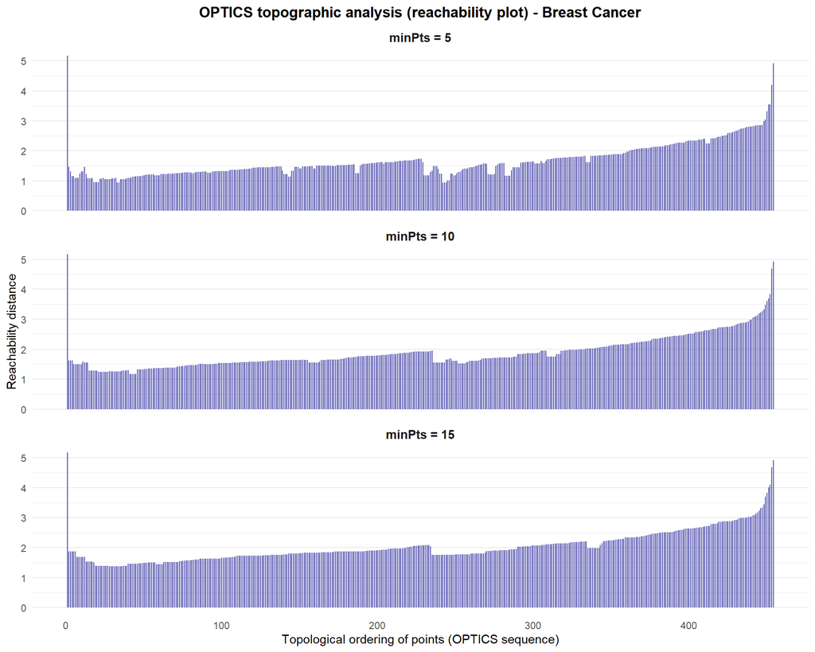

```r
# Evaluate the reachability plots for MinPts values of 5, 10, and 15: Breast Cancer
plot_optics_reachability(X_cancer, minpts_values = base::c(5, 10, 15), dataset_name = "Breast Cancer")
```

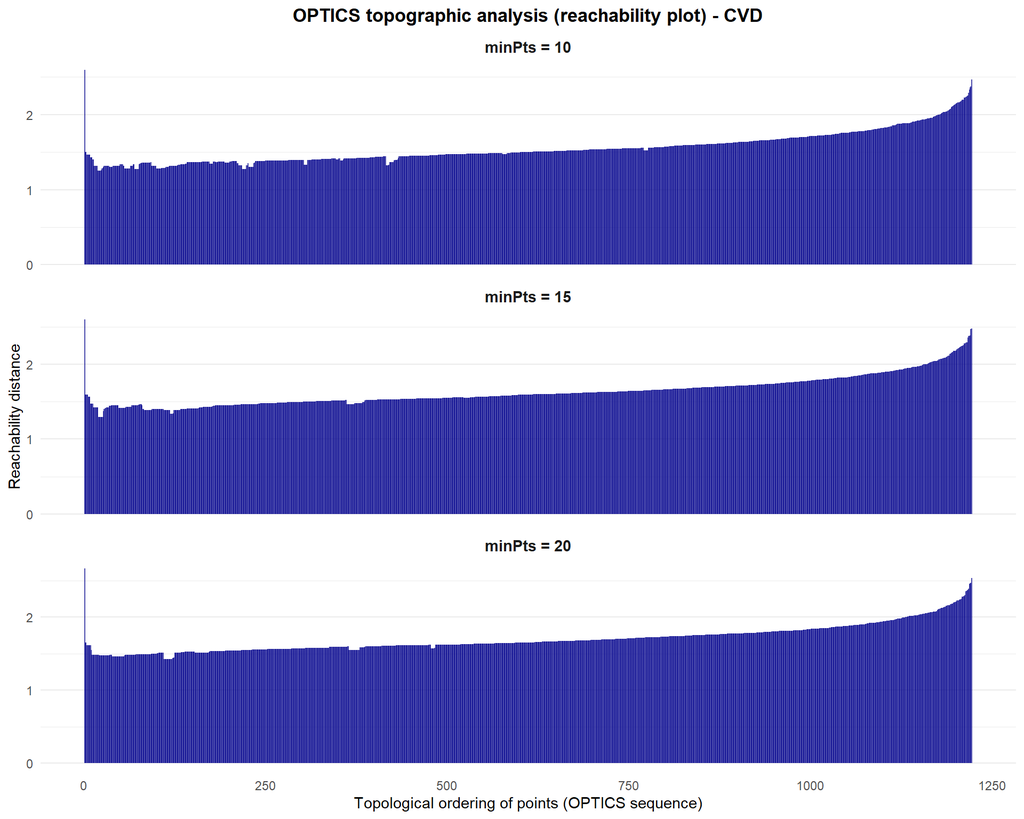

```r
# Evaluate the reachability plots for MinPts values of 10, 15, and 20: CVD
plot_optics_reachability(X_cvd, minpts_values = base::c(10, 15, 20), dataset_name = "CVD")
```

Before interpreting the results, it is essential to understand the nature of these reachability plots. We observe a sequence of vertical lines; each line represents a patient, and its height (the Y axis) shows its reachability distance with respect to its nearest core neighbor. Deep “valleys” represent dense regions of patients (potential clusters), while tall “peaks” indicate low-density zones, transitions, or noise (outliers).

The results faithfully reflect the same complexity we observed in the PCA projection in section 2.3. In neither scenario do we see evident, perfectly separated groups (represented here as isolated valleys surrounded by massive peaks). In the cancer scenario, we see some variability (for example, there is a small topological jump around the center, which hints at a group separation). In the CVD scenario, however, the plot is practically one ascending line or a solid block with no evident valleys we can naturally delimit. We analyze this further in the next subsection.

Regarding the choice of MinPts, we keep the value of 10 in the cancer scenario. At 5, the topography shows too much roughness (micro-clusters with no clinical usefulness). Although 15 is also viable (it does not over-smooth the topology), we consider 10 sufficient, and it perfectly matches the theoretical rule. In the CVD scenario, given the uniform density blob, visually inspecting the plot provides little clarity. We therefore strictly follow the dimensionality rule ($7 \times 2$) and select $MinPts = 15$ for our base model.

## 3.2 Cluster extraction (simulated DBSCAN)

Once we select the optimal MinPts, we obtain a complete ordering of the cohort based on its intrinsic density structure. The mathematical advantage of OPTICS is that the next step does not require training new models from scratch, but simply dissecting the topology we already mapped to extract clusters from it.

To do this, we simulate a DBSCAN execution by performing horizontal cuts on the reachability plot. This operation forces a specific Epsilon ($\epsilon$) value. In this context, $\epsilon$ acts as the maximum threshold defining the density boundary:

1. Any patient sitting inside a valley below this reachability threshold is captured by expansion and assigned to a cluster.
2. Patients exceeding the threshold (appearing as peaks between valleys or as severely isolated points) are filtered out and labeled as clinical noise (cluster 0 / outliers), effectively serving as structural separators between the clusters.

This method allows us to evaluate multiple thresholds simultaneously. We explore a range of $\epsilon$ values based on the visual density heights in each cohort:

- **Breast Cancer:** we run extractions at $\epsilon \in \{2, 1.90, 1.70\}$.
- **Cardiovascular (CVD):** we run extractions at $\epsilon \in \{1.65, 1.55, 1.50\}$.

To evaluate the effect of these cuts, we visualize the topography colored by cluster. Gray points represent noise: patients who, under that level of geometric strictness, do not share enough clinical similarity with their neighbors to form a solid profile.

The goal is to find the medical extraction sweet spot: an $\epsilon$ cut that is too low generates an unacceptable percentage of noise (discarding valuable patients), while an $\epsilon$ that is too permissive merges the entire cohort into a single, useless macro-cluster.

```r
# Run OPTICS once per dataset to build the full reachability ordering
# Note: dbscan::optics() must be run and stored as an object before performing the cuts
base::set.seed(42)
optics_base_cancer <- dbscan::optics(X_cancer, minPts = 10, eps = Inf)
optics_base_cvd    <- dbscan::optics(X_cvd,    minPts = 15, eps = Inf)

# Epsilon thresholds for each scenario, chosen from the visual density heights above
eps_cancer <- base::c(2, 1.90, 1.70)
eps_cvd    <- base::c(1.65, 1.55, 1.50)

# --- A. Simulate DBSCAN by cutting the reachability ordering: Breast Cancer ---
res_cancer_density <- extract_and_plot_dbscan(
  optics_model = optics_base_cancer,
  eps_values   = eps_cancer,
  dataset_name = "Breast Cancer"
)

# --- B. Simulate DBSCAN by cutting the reachability ordering: CVD ---
res_cvd_density <- extract_and_plot_dbscan(
  optics_model = optics_base_cvd,
  eps_values   = eps_cvd,
  dataset_name = "CVD"
)
```

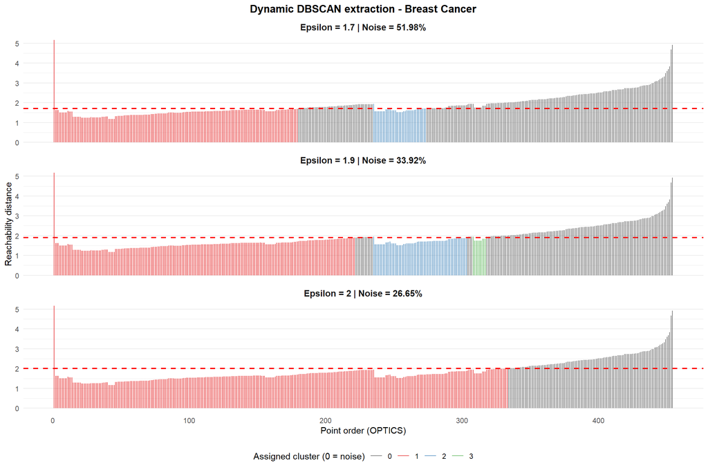

```r
# Display the density topography colored by cluster: Breast Cancer
res_cancer_density$plot
```

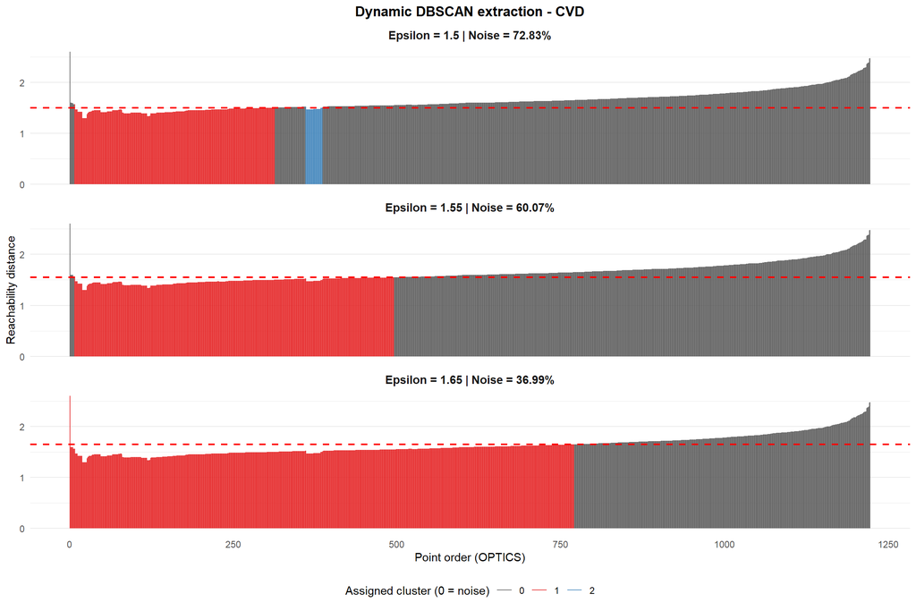

```r
# Display the density topography colored by cluster: CVD
res_cvd_density$plot
```

```r
# Display the extraction statistics (noise rate and group sizes): Breast Cancer
base::print(knitr::kable(res_cancer_density$summary, format = "simple", caption = "Extraction statistics (Breast Cancer)"))
```

```
##
##
## Table: Extraction statistics (Breast Cancer)
##
##  epsilon   num_clusters   noise_patients   noise_percentage
## --------  -------------  ---------------  -----------------
##      2.0              1              121              26.65
##      1.9              3              154              33.92
##      1.7              2              236              51.98
```

```r
# Display the extraction statistics (noise rate and group sizes): CVD
base::print(knitr::kable(res_cvd_density$summary, format = "simple", caption = "Extraction statistics (CVD)"))
```

```
##
##
## Table: Extraction statistics (CVD)
##
##  epsilon   num_clusters   noise_patients   noise_percentage
## --------  -------------  ---------------  -----------------
##     1.65              1              452              36.99
##     1.55              1              734              60.07
##     1.50              2              890              72.83
```

The results of this density-based extraction are, from an operational standpoint, extremely disappointing. The revealed topology does not match the clinical partition we expect based on the target, and the main culprit is a critical metric in biomedicine: the noise rate. In both scenarios, the number of patients discarded for failing to belong to a dense region is enormous.

In the oncological scenario, getting the algorithm to produce at least one clean cut requires raising the threshold to $\epsilon = 1.90$, which already generates an unacceptable ~34% noise rate. On top of that, this cut forces a partition into three groups; looking at the topology, however, the minority group corresponds to a simple variation in the roughness of the plot (a micro-valley), rather than a real biological separation. If we tighten the density threshold to $\epsilon = 1.70$, two groups consolidate, but the noise rate jumps to an alarming ~52%.

In the CVD scenario, the topological situation is even more severe. The point cloud is so homogeneous that, to force the algorithm to find isolated subgroups (at $\epsilon = 1.50$), it labels ~73% of the cohort as noise. The resulting groups are not natural structures, but artificial divisions caused by slight density irregularities, lacking evident valleys or peaks.

These results do not improve even after iterating and adjusting the MinPts hyperparameter to modify the roughness. The geometric explanation for this failure lies in the very nature of the data:

- In the CVD scenario, exactly as we hypothesized initially, we face a multifactorial biological continuum of parameters with complex interdependencies. The dense point cloud features no clear boundaries, making it mathematically impossible for the model to isolate closed groupings. Someone who does not smoke and exercises is easy to group as “healthy.” But what about a patient who smokes but also trains heavily? Or someone with a high BMI but perfect cholesterol? These complex relationships seamlessly blend the groups together and complicate the classification.
- In the cancer scenario, although a theoretical clinical boundary exists between malignant and benign tissue (already confirmed univariately in Notebook 01), a density-based algorithm only perceives the full, continuous spectrum of the variables. Malignancy is also a biological continuum; perimeter, area, and other geometries can take infinitely many continuous values. However, unlike the previous scenario, the variables here do not compensate for one another; cellular atypia pushes all of them jointly in the same direction, meaning it should technically be possible to trace a clear boundary.

  Even so, because of this uninterrupted progression, DBSCAN is unable to isolate dense islands. This contrasts with K-Means and K-Medians, which successfully sectioned the space by drawing a clean geometric plane through the midpoint of PC1 and PC2. Density-based algorithms, operating blind to the target, require empty spaces (sharp density drops) to separate groups. Geometrically, they only find an uninterrupted continuum of morphological measurements. Even though we know clinically that high values correspond to malignant tissue and low values to benign tissue, the algorithm only perceives a gradual transition from one extreme to the other.

  Since there is no deep, evident valley delimiting two large groupings (beyond a faint topographic jump near the center), the model cannot trace a strict boundary and collapses. Still, we anticipate that the supervised models in the next phase (like Random Forest) will easily find the optimal cut points along this continuous spectrum, since they actively incorporate the target variable during training (for example, branching whenever radius > x).

Our initial project outline planned an internal comparative analysis at this stage, comparing the best Epsilon values using DBCV (Density-Based Clustering Validation) and selecting the optimal model for phase 4. We decide against this. The reason is simple: in cardiovascular risk and malignancy detection models, where the absolute priority is identifying severe clinical profiles, it is unacceptable to discard more than 30% (let alone 70%) of the population by simply labeling it as algorithmic noise.

We do not want to select models that we already know with certainty perform poorly on the Notebook 04 metrics and lack clinical utility. Therefore, although density-based algorithms form a very powerful family with genuine theoretical advantages over centroid-based methods, we discard this family of models entirely for this project. We focus exclusively on the centroid-based models (K-Means and K-Medians), which, although less sophisticated geometrically, offer full cohort coverage and far more direct clinical interpretability.